# MUM 2023 Optymalizatory podsumowanie

1. zbiór uczący, treningowy
   - reprezentuje dane
     - zmienne ciągłe (float'y)
     - kategorie (int'y)
   - funkcja kosztu jako średnia kosztu po wszystkich przykładach
2. zbiór testowy
   - oddzielnie od zbioru treningowego
   - **takie same**, ale nie **te same** dane
   - służy do oceny nauczonego modelu
3. **postać** funkcji kosztu
   - **model liniowy** wypukła, jedno minimum globalne
     - **elipsoida** dla problemów regresji liniowej
     - **bardzo wąska** utrudni
     - **normalizacja**
   - **nieliniowe modele** wiele minimów lokalnych
     - **bardzo zróżnicowana** dla złożonych modeli
   - szerokie *plateau*
     - niska wartość gradientu
     - powolne uczenie
4. numeryczne sprawdzanie gradientów
   - metody różnicowe
   - ważne, jeśli sami piszemy model
5. **stochastyczność** algorytmu
   - **Stochastic** Gradient Descent
     - pojedyncze przykłady
   - **mini-batch**
     - zwykle kilka do kilkadziesiąt przykładów
   - **epoka**
     - każdy przykład treningowy wzięty dokładnie raz
   - niezbędne dla bardzo dużych datasetów
     - np. GPU ma ograniczoną RAM
   - **szybki**, ale **niedokładny**

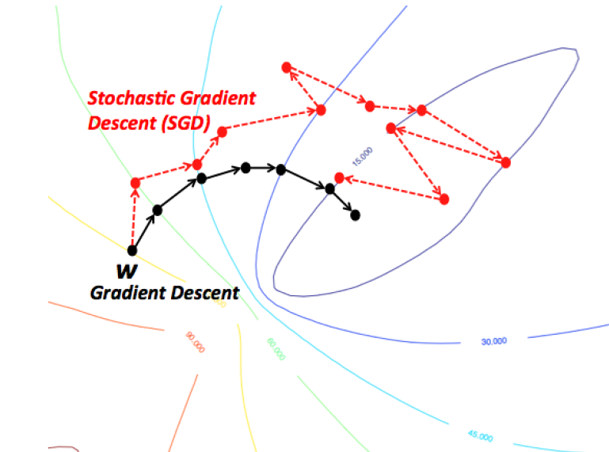

6. Jak w praktyce korzystać z optimizerów
   - **mieszanie** przykładów treningowych
     - przykłady brać losowo - wystarczy mieszać po epoce
     - przykład z tej samej klasy lub o podobnej wartości *nie* obok siebie
   - **śledzenie** błędu trenowania i walidacji
   - uczyć przez wiele epok
   - **eksperymentowanie** z parametrami optimizera
     - mały podzbiór zbioru treningowego
     - mniej epok
     - wypisywać błąd co minibatch
   - **normalizacja** parametrów początkowych
     - w zależności od modelu
     - pozwala na wyższe wartości $\eta$
7. warto testować różne optimizery
   - RMSprop i Adadelta bardzo podobne
   - Adam dodaje lepsze podejście do biasu
   - Gradient Descent ma wady, ale też działa
8. możliwe modyfikowanie parametrów optimizera w czasie
   - *learning rate schedule*
     - **duże**
       - szybkie ale niestabilne
       - może ominąć minimum
     - **małe**
       - stabilne ale powolne
9. **urównoleglenie** uczenia
   - wiele równoległych kopii modelu
   - centarlny serwer łączący modyfikacje
10. **gradient clipping**
    - **gradient explosion problem**
    - ręcznie ograniczamy maksymalną normę gradientu